# Metagenomika i filogenetyka molekularna: Autotroficzne eugleniny w małych zbiornikach wodnych

Julia Smolik

# Wczytanie bibliotek

```r
suppressWarnings(library(fansi))
suppressWarnings(library(dplyr))
suppressWarnings(library(plyr))
suppressWarnings(library(vegan))
suppressWarnings(library(tidyverse))
suppressWarnings(library(ggplot2))
suppressWarnings(library(phyloseq))
suppressWarnings(library(qiime2R))
suppressWarnings(library(picante))
```

# Wczytanie danych

Wczytuję dane i tworzę obiekt Phyloseq

```r
phyloseq = qza_to_phyloseq(features = "../table_output.qza", tree = "../rooted_tree.qza",taxonomy = "../taxonomy.qza", metadata = "../sample_metadata.tsv")
```

# Podstawowe informacje o danych

Sprawdzam liczbę taksonów i próbek, maksymalną i minimalną liczbę odczytów w próbce, poziomy taksonomiczne

```r
ntaxa(phyloseq)
```

```
[1] 1731
```

```r
nsamples(phyloseq)
```

```
[1] 24
```

```r
max(sample_sums(phyloseq))
```

```
[1] 24641
```

```r
min(sample_sums(phyloseq))
```

```
[1] 10197
```

```r
rank_names(phyloseq)
```

```
[1] "Kingdom" "Phylum"  "Class"   "Order"   "Family"  "Genus"   "Species"
```

# Filtrowanie danych - przedstawiciele Euglenida

Wybieram tylko te odczyty, których przedstawiciele należą do Euglenida

```r
phyloseq_euglenida <- subset_taxa(phyloseq, Order == "Euglenida")
```

Sprawdzam liczbę taksonów i próbek, maksymalną i minimalną liczbę odczytów w próbce, poziomy taksonomiczne w filtrowanych danych

```r
ntaxa(phyloseq_euglenida)
```

```
[1] 1609
```

```r
nsamples(phyloseq_euglenida)
```

```
[1] 24
```

```r
max(sample_sums(phyloseq_euglenida))
```

```
[1] 21827
```

```r
min(sample_sums(phyloseq_euglenida))
```

```
[1] 10188
```

```r
rank_names(phyloseq_euglenida)
```

```
[1] "Kingdom" "Phylum"  "Class"   "Order"   "Family"  "Genus"   "Species"
```

W porównaniu do kompletnych danych, przefiltrowane dane są mniejsze - zawierają mniej taksonów, ale także mają mniejszą maksymalną i minimalną liczbę odczytów w próbce. Poziomy taksonomiczne pozostały bez zmian. Do dalszych analiz będę zatem używała odczytów, które należą do Euglenida.

# Łączenie ASV z tych samych gatunków

Sprawdzam przyporządkowanie taksonomiczne

```r
tax_table(phyloseq_euglenida)[1:20, 1:7]
```

```
Taxonomy Table:     [20 taxa by 7 taxonomic ranks]:
                                 Kingdom     Phylum     Class     Order       Family        Genus
3e08234b0578723bf2199340c3d94efe "Eukaryota" "Excavata" "Discoba" "Euglenida" "Euglenaceae" "Strombomonas"
df69ce7f69ac5a14488fec0a045f5125 "Eukaryota" "Excavata" "Discoba" "Euglenida" "Euglenaceae" "Strombomonas"
2c265920e31f9203159d8daf3aba1f5a "Eukaryota" "Excavata" "Discoba" "Euglenida" "Euglenaceae" "Strombomonas"
7044544281b955ff0ceaee16373f3111 "Eukaryota" "Excavata" "Discoba" "Euglenida" "Euglenaceae" "Strombomonas"
a8d367ff3e5df6c0b9c9f0e16bb9a46d "Eukaryota" "Excavata" "Discoba" "Euglenida" "Euglenaceae" "Strombomonas"
564cb6a44928a0e1035b9bd23d456b77 "Eukaryota" "Excavata" "Discoba" "Euglenida" "Euglenaceae" "Strombomonas"
354d1f84c044a937703a77d32e6aebc1 "Eukaryota" "Excavata" "Discoba" "Euglenida" "Euglenaceae" "Strombomonas"
79a18eb5f8af707d72fd8e89d4b66edd "Eukaryota" "Excavata" "Discoba" "Euglenida" "Euglenaceae" "Strombomonas"
c3edc4aabd39575e3530b4f58b1ff7f3 "Eukaryota" "Excavata" "Discoba" "Euglenida" "Euglenaceae" NA
781a37fde2949eb9c7339c5bc6926ac5 "Eukaryota" "Excavata" "Discoba" "Euglenida" "Euglenaceae" "Strombomonas"
5f27f7c1072be243a443e28f0021bc45 "Eukaryota" "Excavata" "Discoba" "Euglenida" "Euglenaceae" "Strombomonas"
50a53c1814078e61b3e325dbfd4b8871 "Eukaryota" "Excavata" "Discoba" "Euglenida" "Euglenaceae" "Strombomonas"
16c06ae6836681f8747edd534ea2c7e2 "Eukaryota" "Excavata" "Discoba" "Euglenida" "Euglenaceae" "Strombomonas"
b95c684c45803f0bf619a12e07e3286a "Eukaryota" "Excavata" "Discoba" "Euglenida" "Euglenaceae" "Strombomonas"
a1beb1b3de23e201fcbb4066a9f03ac1 "Eukaryota" "Excavata" "Discoba" "Euglenida" "Euglenaceae" "Strombomonas"
e9d88e75a95b3e9ce6199c48d65af934 "Eukaryota" "Excavata" "Discoba" "Euglenida" "Euglenaceae" "Strombomonas"
938cbddf28f0773988f58a9327ac9167 "Eukaryota" "Excavata" "Discoba" "Euglenida" "Euglenaceae" "Strombomonas"
de3101e77798ba61df4cc177173529fd "Eukaryota" "Excavata" "Discoba" "Euglenida" "Euglenaceae" "Strombomonas"
4d4480be2894f09f18c03371a81307fa "Eukaryota" "Excavata" "Discoba" "Euglenida" "Euglenaceae" "Strombomonas"
b05bb27ac9ddea225db70bfd60676f35 "Eukaryota" "Excavata" "Discoba" "Euglenida" "Euglenaceae" "Strombomonas"
                                 Species
3e08234b0578723bf2199340c3d94efe "D_10__Strombomonas fluviatilis"
df69ce7f69ac5a14488fec0a045f5125 "D_10__Strombomonas maxima"
2c265920e31f9203159d8daf3aba1f5a NA
7044544281b955ff0ceaee16373f3111 "D_10__Strombomonas maxima"
a8d367ff3e5df6c0b9c9f0e16bb9a46d "D_10__Strombomonas maxima"
564cb6a44928a0e1035b9bd23d456b77 "D_10__Strombomonas fluviatilis"
354d1f84c044a937703a77d32e6aebc1 "D_10__Strombomonas acuminata"
79a18eb5f8af707d72fd8e89d4b66edd "D_10__Strombomonas acuminata"
c3edc4aabd39575e3530b4f58b1ff7f3 NA
781a37fde2949eb9c7339c5bc6926ac5 "D_10__Strombomonas verrucosa"
5f27f7c1072be243a443e28f0021bc45 "D_10__Strombomonas verrucosa"
50a53c1814078e61b3e325dbfd4b8871 "D_10__Strombomonas verrucosa"
16c06ae6836681f8747edd534ea2c7e2 "D_10__Strombomonas triquetra"
b95c684c45803f0bf619a12e07e3286a "D_10__Strombomonas triquetra"
a1beb1b3de23e201fcbb4066a9f03ac1 "D_10__Strombomonas triquetra"
e9d88e75a95b3e9ce6199c48d65af934 NA
938cbddf28f0773988f58a9327ac9167 "D_10__Strombomonas triquetra"
de3101e77798ba61df4cc177173529fd "D_10__Strombomonas triquetra"
4d4480be2894f09f18c03371a81307fa "D_10__Strombomonas schauinslandii"
b05bb27ac9ddea225db70bfd60676f35 "D_10__Strombomonas schauinslandii"
```

```r
tax_table(phyloseq_euglenida)[1589:1609, 1:7]
```

```
Taxonomy Table:     [21 taxa by 7 taxonomic ranks]:
                                 Kingdom     Phylum     Class     Order       Family        Genus
46902a3b58f2fdd47db07ab97f87d752 "Eukaryota" "Excavata" "Discoba" "Euglenida" "Euglenaceae" "Trachelomonas"
ae8a4d797f8e3dece67e61516d5bdb83 "Eukaryota" "Excavata" "Discoba" "Euglenida" "Euglenaceae" "Trachelomonas"
8c5562f52d4d49fb784a350a078c2ba5 "Eukaryota" "Excavata" "Discoba" "Euglenida" "Euglenaceae" "Trachelomonas"
e447cd0b64cfe2f052076dfd61e799e3 "Eukaryota" "Excavata" "Discoba" "Euglenida" "Euglenaceae" "Trachelomonas"
99df6b37ae090998484acdaa2823c721 "Eukaryota" "Excavata" "Discoba" "Euglenida" "Euglenaceae" "Trachelomonas"
59d2205677ae4d2d55381ad9df617251 "Eukaryota" "Excavata" "Discoba" "Euglenida" "Euglenaceae" "Trachelomonas"
fe4996ede0cc114227eb867268311a0f "Eukaryota" "Excavata" "Discoba" "Euglenida" "Euglenaceae" "Trachelomonas"
42d685f225c79f29d512f2deb97ac923 "Eukaryota" "Excavata" "Discoba" "Euglenida" "Euglenaceae" "Trachelomonas"
7735d5a32c709e70a181180879d730ed "Eukaryota" "Excavata" "Discoba" "Euglenida" "Euglenaceae" "Trachelomonas"
3452f4cfc4c64b6c82eb8b8e03eb5114 "Eukaryota" "Excavata" "Discoba" "Euglenida" "Euglenaceae" "Trachelomonas"
eb92b058515aea65e5f2e63b37ef9375 "Eukaryota" "Excavata" "Discoba" "Euglenida" "Euglenaceae" "Trachelomonas"
24cc370ae8a4e2b00c8b71d252ea3e0c "Eukaryota" "Excavata" "Discoba" "Euglenida" "Euglenaceae" "Trachelomonas"
ec9b1ecc0fccb1aef783adf749e662f8 "Eukaryota" "Excavata" "Discoba" "Euglenida" "Euglenaceae" "Trachelomonas"
af51c3ebc8761d42e4b3559b08c15e6e "Eukaryota" "Excavata" "Discoba" "Euglenida" "Euglenaceae" "Trachelomonas"
1127995efe19b7116dddedab9c5052f3 "Eukaryota" "Excavata" "Discoba" "Euglenida" "Euglenaceae" "Trachelomonas"
0e2e0b9f99f38c5f7d756a1b77a28195 "Eukaryota" "Excavata" "Discoba" "Euglenida" "Euglenaceae" "Trachelomonas"
546c61b857db3572bc1d3cea74893d5e "Eukaryota" "Excavata" "Discoba" "Euglenida" "Euglenaceae" "Trachelomonas"
d9009c6ae559bc7155354ac2fada2d16 "Eukaryota" "Excavata" "Discoba" "Euglenida" "Euglenaceae" "Trachelomonas"
924075902e5c8d005c906834b5210036 "Eukaryota" "Excavata" "Discoba" "Euglenida" "Euglenaceae" "Trachelomonas"
c75a6e9b08870722ddca1f76a3989557 "Eukaryota" "Excavata" "Discoba" "Euglenida" "Euglenaceae" "Trachelomonas"
849d76f6172e474b597d1ba2a65b9807 "Eukaryota" "Excavata" "Discoba" "Euglenida" "Euglenaceae" "Trachelomonas"
                                 Species
46902a3b58f2fdd47db07ab97f87d752 "D_10__Trachelomonas compacta"
ae8a4d797f8e3dece67e61516d5bdb83 "D_10__Trachelomonas compacta"
8c5562f52d4d49fb784a350a078c2ba5 "D_10__Trachelomonas compacta"
e447cd0b64cfe2f052076dfd61e799e3 "D_10__Trachelomonas compacta"
99df6b37ae090998484acdaa2823c721 "D_10__Trachelomonas compacta"
59d2205677ae4d2d55381ad9df617251 "D_10__Trachelomonas compacta"
fe4996ede0cc114227eb867268311a0f "D_10__Trachelomonas compacta"
42d685f225c79f29d512f2deb97ac923 "D_10__Trachelomonas compacta"
7735d5a32c709e70a181180879d730ed "D_10__Trachelomonas compacta"
3452f4cfc4c64b6c82eb8b8e03eb5114 "D_10__Trachelomonas manschurica"
eb92b058515aea65e5f2e63b37ef9375 "D_10__Trachelomonas compacta"
24cc370ae8a4e2b00c8b71d252ea3e0c "D_10__Trachelomonas compacta"
ec9b1ecc0fccb1aef783adf749e662f8 "D_10__Trachelomonas compacta"
af51c3ebc8761d42e4b3559b08c15e6e "D_10__Trachelomonas compacta"
1127995efe19b7116dddedab9c5052f3 "D_10__Trachelomonas compacta"
0e2e0b9f99f38c5f7d756a1b77a28195 "D_10__Trachelomonas compacta"
546c61b857db3572bc1d3cea74893d5e "D_10__Trachelomonas compacta"
d9009c6ae559bc7155354ac2fada2d16 "D_10__Trachelomonas compacta"
924075902e5c8d005c906834b5210036 "D_10__Trachelomonas compacta"
c75a6e9b08870722ddca1f76a3989557 "D_10__Trachelomonas compacta"
849d76f6172e474b597d1ba2a65b9807 "D_10__Trachelomonas compacta"
```

Sprawdzam ile jest unikatowych przyporządkowań taksonomicznych na poziomie gatunku

```r
unique_euglenida = get_taxa_unique(phyloseq_euglenida, taxonomic.rank=rank_names(phyloseq_euglenida)[7])
ntaxa(phyloseq_euglenida)
```

```
[1] 1609
```

```r
length(unique_euglenida)
```

```
[1] 131
```

Ponieważ niewiele przyporządkowań na poziomie gatunku jest nieznanych (mało wartości NaN) i jest tylko 131 unikatowych gatunków, wydaje się, że połączenie ASV z tych samych gatunków będzie dobrą decyzją. Usprawni to obliczenia i pozwoli na bardziej czytelną wizualizację wyników, przy niewielkiej stracie danych. Dalsze analizy przeprowadzę zatem na ASV połączonych dla tych samych gatunków.

```r
phyloseq_glom <- tax_glom(phyloseq_euglenida, "Species")
```

Sprawdzam liczbę taksonów i próbek, maksymalną i minimalną liczbę odczytów w próbce, poziomy taksonomiczne w połączonych danych

```r
ntaxa(phyloseq_glom)
```

```
[1] 130
```

```r
nsamples(phyloseq_glom)
```

```
[1] 24
```

```r
max(sample_sums(phyloseq_glom))
```

```
[1] 21208
```

```r
min(sample_sums(phyloseq_glom))
```

```
[1] 7268
```

```r
rank_names(phyloseq_glom)
```

```
[1] "Kingdom" "Phylum"  "Class"   "Order"   "Family"  "Genus"   "Species"
```

# Krzywa wysycenia

Tworzę krzywą alfa-curve

```
most observed count data have counts 1, but smallest count is 2
```

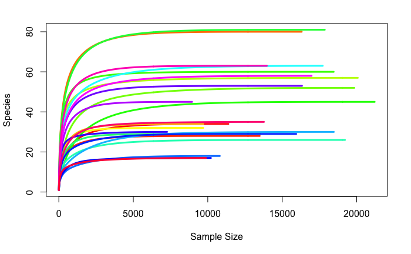

```r
tab = data.frame(t(otu_table(phyloseq_glom)))
#png(file="../images/alfa-curve.png", width=800, height=600, res=100)
rarecurve(tab, step=50, cex=0.9, label=FALSE, col=rainbow(24), lwd = 3)
```

```r
#dev.off()
```

Na podstawie krzywej można stwierdzć, że liczba odczytów w najmniej licznej próbce wydaje się wystarczająca, żeby można było do tej wartości ograniczyć liczbę odczytów we wszystkich próbkach bez znaczącej straty informacji o bogactwie gatunkowym i różnorodności biologicznej. Najmniej liczna próbka zawiera 7268 odczytów. Jest to mniej więcej 1/3 liczebności odczytów w najbardziej licznej próbce, ale w porównaniu z resztą próbek ta wartość nie odbiega znacząco. Najprawdopodobniej pewne dane zostaną utracone, ale warto ograniczyć liczbę odczytów, ponieważ usprawni to obliczenia, a sama strata będzie niekrytyczna. Wszystkie próbki ograniczę zatem do 7268 odczytów.

# Rarefaction

Ograniczam liczbę odczytów we wszystkich próbkach

```r
phyloseq_rare <- rarefy_even_depth(phyloseq_glom, sample.size=min(sample_sums((phyloseq_glom))), replace=F)
```

```
You set `rngseed` to FALSE. Make sure you've set & recorded
 the random seed of your session for reproducibility.
See `?set.seed`

...
```

Sprawdzam liczbę taksonów i próbek, maksymalną i minimalną liczbę odczytów w próbce, poziomy taksonomiczne w ograniczonych danych

```r
ntaxa(phyloseq_rare)
```

```
[1] 130
```

```r
nsamples(phyloseq_rare)
```

```
[1] 24
```

```r
max(sample_sums(phyloseq_rare))
```

```
[1] 7268
```

```r
min(sample_sums(phyloseq_rare))
```

```
[1] 7268
```

```r
rank_names(phyloseq_rare)
```

```
[1] "Kingdom" "Phylum"  "Class"   "Order"   "Family"  "Genus"   "Species"
```

Po ograniczeniu danych nie utracono żadnych taksonów, ani żadnej próbki. Wydaje się, że ograniczenie odczytów w próbkach nie zaburzyło znacząco danych i ich różnorodności.

# Analiza alfa-różnorodności

```r
c25 <- c(
  "dodgerblue2", "#E31A1C", # red
  "green4",
  "#6A3D9A", # purple
  "#FF7F00", # orange
  "black", "gold1",
  "skyblue2", "#FB9A99", # lt pink
  "palegreen2",
  "#CAB2D6", # lt purple
  "#FDBF6F", # lt orange
  "gray70", "khaki2",
  "maroon", "orchid1", "deeppink1", "blue1", "steelblue4",
  "darkturquoise", "green1", "yellow4", "yellow3",
  "darkorange4", "brown"
)
```

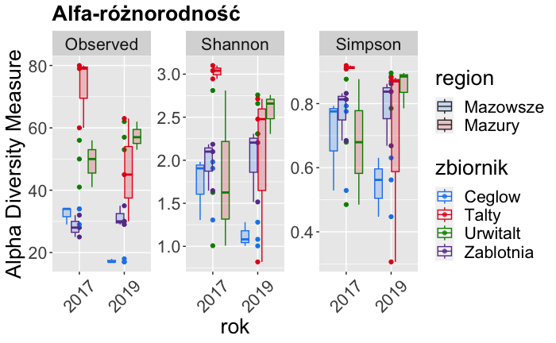

```r
diversity <- estimate_richness(phyloseq_rare, measures = c("Observed", "Shannon", "Simpson"))
data_alphadiv <- cbind(sample_data(phyloseq_rare), diversity)
```

```r
summary(aov(Observed ~ rok, data = data_alphadiv))
```

```
            Df Sum Sq Mean Sq F value Pr(>F)
rok          1    353   352.7   1.041  0.319
Residuals   22   7455   338.8
```

```r
summary(aov(Observed ~ zbiornik, data = data_alphadiv))
```

```
            Df Sum Sq Mean Sq F value   Pr(>F)
zbiornik     3   5241  1747.1   13.62 4.56e-05 ***
Residuals   20   2566   128.3
---
Signif. codes:  0 ‘***’ 0.001 ‘**’ 0.01 ‘*’ 0.05 ‘.’ 0.1 ‘ ’ 1
```

```r
summary(aov(Observed ~ region, data = data_alphadiv))
```

```
            Df Sum Sq Mean Sq F value   Pr(>F)
region       1   5046    5046    40.2 2.22e-06 ***
Residuals   22   2761     126
---
Signif. codes:  0 ‘***’ 0.001 ‘**’ 0.01 ‘*’ 0.05 ‘.’ 0.1 ‘ ’ 1
```

```r
summary(aov(Shannon ~ rok, data = data_alphadiv))
```

```
            Df Sum Sq Mean Sq F value Pr(>F)
rok          1  0.266  0.2659   0.518  0.479
Residuals   22 11.287  0.5130
```

```r
summary(aov(Shannon ~ zbiornik, data = data_alphadiv))
```

```
            Df Sum Sq Mean Sq F value Pr(>F)
zbiornik     3  3.769  1.2563   3.228 0.0443 *
Residuals   20  7.784  0.3892
---
Signif. codes:  0 ‘***’ 0.001 ‘**’ 0.01 ‘*’ 0.05 ‘.’ 0.1 ‘ ’ 1
```

```r
summary(aov(Shannon ~ region, data = data_alphadiv))
```

```
            Df Sum Sq Mean Sq F value Pr(>F)
region       1  2.496  2.4962   6.064 0.0221 *
Residuals   22  9.057  0.4117
---
Signif. codes:  0 ‘***’ 0.001 ‘**’ 0.01 ‘*’ 0.05 ‘.’ 0.1 ‘ ’ 1
```

```r
summary(aov(Simpson ~ rok, data = data_alphadiv))
```

```
            Df Sum Sq Mean Sq F value Pr(>F)
rok          1 0.0139 0.01390   0.464  0.503
Residuals   22 0.6585 0.02993
```

```r
summary(aov(Simpson ~ zbiornik, data = data_alphadiv))
```

```
            Df Sum Sq Mean Sq F value Pr(>F)
zbiornik     3 0.1186 0.03952   1.427  0.264
Residuals   20 0.5539 0.02769
```

```r
summary(aov(Simpson ~ region, data = data_alphadiv))
```

```
            Df Sum Sq Mean Sq F value Pr(>F)
region       1 0.0388  0.0388   1.347  0.258
Residuals   22 0.6336  0.0288
```

# Beta-różnorodność

## Macierze odległości

```r
library(reshape2)
plot_dist_as_heatmap <- function(dist, order = sampleOrder, title = NULL) {
  data <- melt(as(dist, "matrix"))
  colnames(data) <- c("x", "y", "distance")
  if (!is.null(order)) {
    data$x <- factor(data$x, levels = order)
    data$y <- factor(data$y, levels = order)
  }
  p <- ggplot(data, aes(x = x, y = y, fill = distance)) + geom_tile()
  p <- p + theme(axis.title.x = element_blank(),
                 axis.title.y = element_blank(),
                 #axis.text.x = element_blank(),
                 #axis.text.y = element_blank()
  )
  p <- p + scale_fill_continuous(limits = c(0, 1))
  if (!is.null(title)) {
    p <- p + ggtitle(title)
  }
  return(p)
}

sampleOrder = levels(reorder(sample_names(phyloseq_rare), as.numeric(get_variable(phyloseq_rare, "zbiornik"))))
```

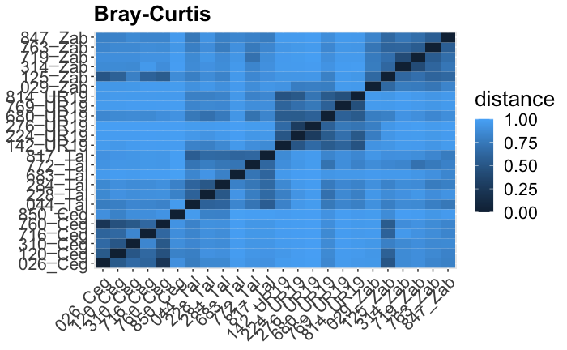

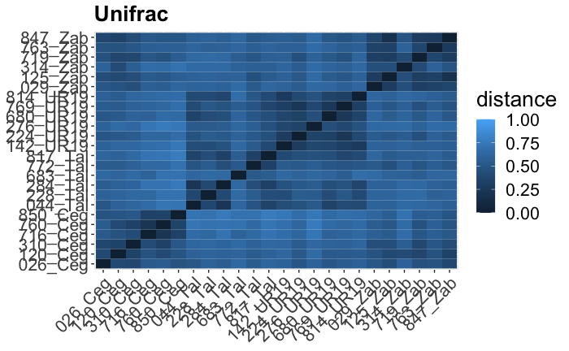

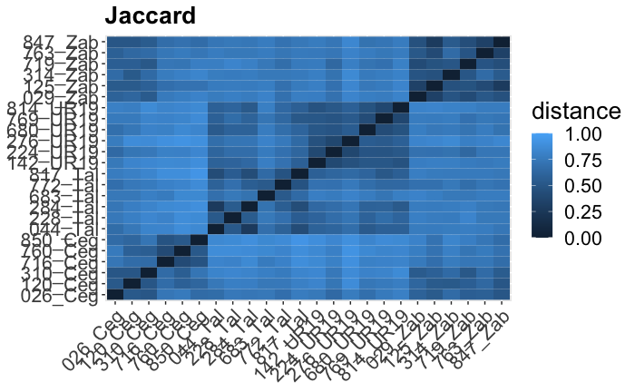

## Ordynacje

### Najprostsza ordynacja - dendogramy

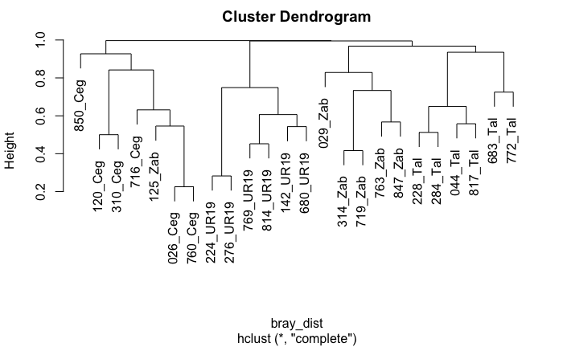

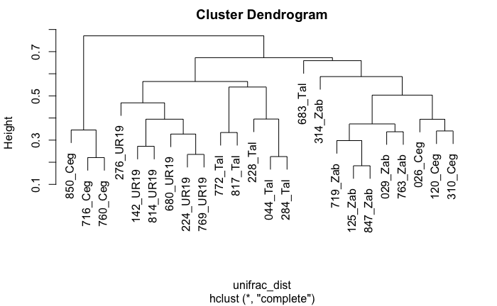

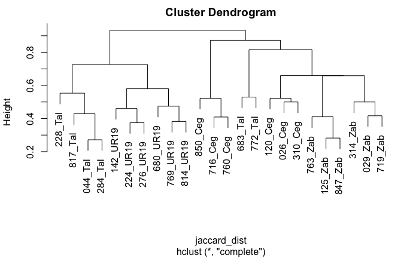

### NMDS

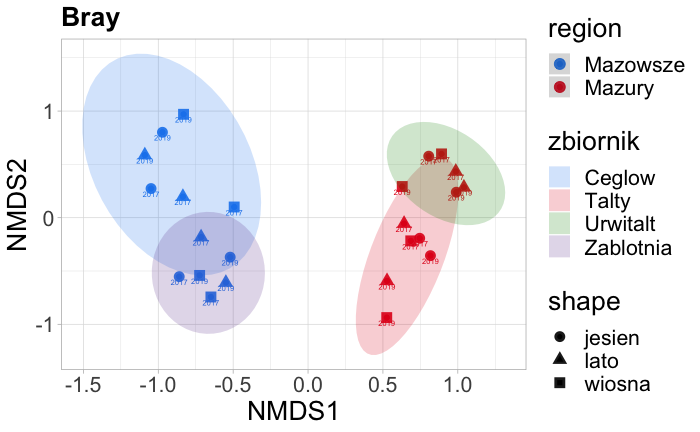

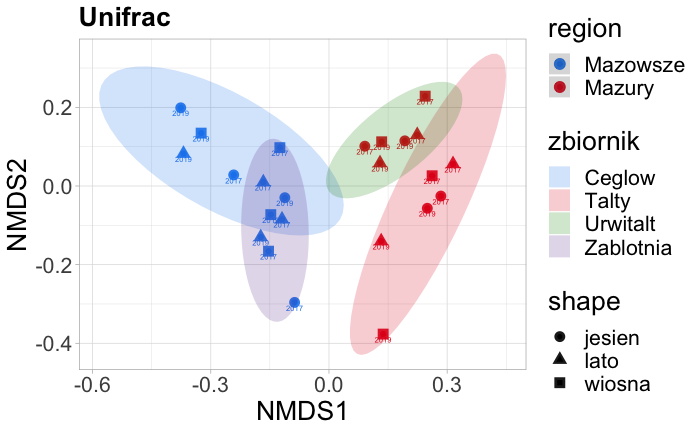

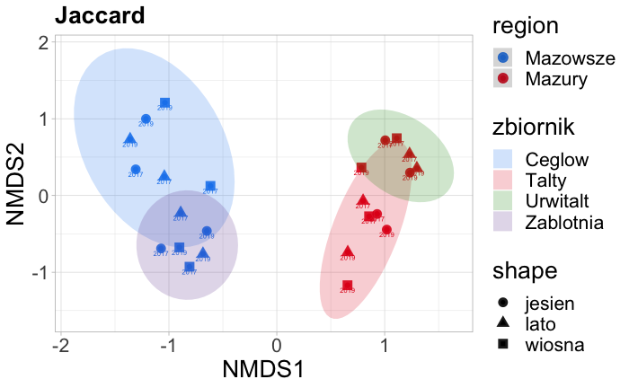

## Anosim

```r
rok = get_variable(phyloseq_rare, "rok")
zb = get_variable(phyloseq_rare, "zbiornik")
region = get_variable(phyloseq_rare, "region")
```

```r
anosim(bray_dist, grouping = rok)
```

```
Call:
anosim(x = bray_dist, grouping = rok)
Dissimilarity: bray

ANOSIM statistic R: -0.01357
      Significance: 0.508

Permutation: free
Number of permutations: 999
```

```r
anosim(bray_dist, grouping = zb)
```

```
Call:
anosim(x = bray_dist, grouping = zb)
Dissimilarity: bray

ANOSIM statistic R: 0.8699
      Significance: 0.001

Permutation: free
Number of permutations: 999
```

```r
anosim(bray_dist, grouping = region)
```

```
Call:
anosim(x = bray_dist, grouping = region)
Dissimilarity: bray

ANOSIM statistic R: 0.5683
      Significance: 0.001

Permutation: free
Number of permutations: 999
```

```r
anosim(unifrac_dist, grouping = rok)
```

```
Call:
anosim(x = unifrac_dist, grouping = rok)
Dissimilarity:

ANOSIM statistic R: 0.0241
      Significance: 0.238

Permutation: free
Number of permutations: 999
```

```r
anosim(unifrac_dist, grouping = zb)
```

```
Call:
anosim(x = unifrac_dist, grouping = zb)
Dissimilarity:

ANOSIM statistic R: 0.7801
      Significance: 0.001

Permutation: free
Number of permutations: 999
```

```r
anosim(unifrac_dist, grouping = region)
```

```
Call:
anosim(x = unifrac_dist, grouping = region)
Dissimilarity:

ANOSIM statistic R: 0.7837
      Significance: 0.001

Permutation: free
Number of permutations: 999
```

```r
anosim(jaccard_dist, grouping = rok)
```

```
Call:
anosim(x = jaccard_dist, grouping = rok)
Dissimilarity: binary jaccard

ANOSIM statistic R: 0.03083
      Significance: 0.244

Permutation: free
Number of permutations: 999
```

```r
anosim(jaccard_dist, grouping = zb)
```

```
Call:
anosim(x = jaccard_dist, grouping = zb)
Dissimilarity: binary jaccard

ANOSIM statistic R: 0.8645
      Significance: 0.001

Permutation: free
Number of permutations: 999
```

```r
anosim(jaccard_dist, grouping = region)
```

```
Call:
anosim(x = jaccard_dist, grouping = region)
Dissimilarity: binary jaccard

ANOSIM statistic R: 0.8572
      Significance: 0.001

Permutation: free
Number of permutations: 999
```

## Permanova

```r
metadane <- data.frame(sample_data(phyloseq_rare))
```

```r
adonis(bray_dist ~ rok, data = metadane)$aov.tab
```

```
'adonis' will be deprecated: use 'adonis2' instead
```

```
Permutation: free
Number of permutations: 999

Terms added sequentially (first to last)

          Df SumsOfSqs MeanSqs F.Model      R2 Pr(>F)
rok        1    0.3371 0.33706 0.90868 0.03967  0.519
Residuals 22    8.1604 0.37093         0.96033
Total     23    8.4975                 1.00000
```

```r
adonis(bray_dist ~ zbiornik, data = metadane)$aov.tab
```

```
'adonis' will be deprecated: use 'adonis2' instead
```

```
Permutation: free
Number of permutations: 999

Terms added sequentially (first to last)

          Df SumsOfSqs MeanSqs F.Model      R2 Pr(>F)
zbiornik   3    4.1254  1.3751  6.2906 0.48549  0.001 ***
Residuals 20    4.3721  0.2186         0.51451
Total     23    8.4975                 1.00000
---
Signif. codes:  0 ‘***’ 0.001 ‘**’ 0.01 ‘*’ 0.05 ‘.’ 0.1 ‘ ’ 1
```

```r
adonis(bray_dist ~ region, data = metadane)$aov.tab
```

```
'adonis' will be deprecated: use 'adonis2' instead
```

```
Permutation: free
Number of permutations: 999

Terms added sequentially (first to last)

          Df SumsOfSqs MeanSqs F.Model      R2 Pr(>F)
region     1    1.6844 1.68442  5.4391 0.19823  0.001 ***
Residuals 22    6.8131 0.30969         0.80177
Total     23    8.4975                 1.00000
---
Signif. codes:  0 ‘***’ 0.001 ‘**’ 0.01 ‘*’ 0.05 ‘.’ 0.1 ‘ ’ 1
```

```r
adonis(unifrac_dist ~ rok, data = metadane)$aov.tab
```

```
'adonis' will be deprecated: use 'adonis2' instead
```

```
Permutation: free
Number of permutations: 999

Terms added sequentially (first to last)

          Df SumsOfSqs MeanSqs F.Model      R2 Pr(>F)
rok        1    0.1903 0.19032  1.2949 0.05559   0.23
Residuals 22    3.2337 0.14699         0.94441
Total     23    3.4240                 1.00000
```

```r
adonis(unifrac_dist ~ zbiornik, data = metadane)$aov.tab
```

```
'adonis' will be deprecated: use 'adonis2' instead
```

```
Permutation: free
Number of permutations: 999

Terms added sequentially (first to last)

          Df SumsOfSqs MeanSqs F.Model    R2 Pr(>F)
zbiornik   3    1.7599 0.58664  7.0507 0.514  0.001 ***
Residuals 20    1.6641 0.08320         0.486
Total     23    3.4240                 1.000
---
Signif. codes:  0 ‘***’ 0.001 ‘**’ 0.01 ‘*’ 0.05 ‘.’ 0.1 ‘ ’ 1
```

```r
adonis(unifrac_dist ~ region, data = metadane)$aov.tab
```

```
'adonis' will be deprecated: use 'adonis2' instead
```

```
Permutation: free
Number of permutations: 999

Terms added sequentially (first to last)

          Df SumsOfSqs MeanSqs F.Model      R2 Pr(>F)
region     1    1.0644 1.06443  9.9246 0.31088  0.001 ***
Residuals 22    2.3596 0.10725         0.68912
Total     23    3.4240                 1.00000
---
Signif. codes:  0 ‘***’ 0.001 ‘**’ 0.01 ‘*’ 0.05 ‘.’ 0.1 ‘ ’ 1
```

```r
adonis(jaccard_dist ~ rok, data = metadane)$aov.tab
```

```
'adonis' will be deprecated: use 'adonis2' instead
```

```
Permutation: free
Number of permutations: 999

Terms added sequentially (first to last)

          Df SumsOfSqs MeanSqs F.Model      R2 Pr(>F)
rok        1    0.3141 0.31412  1.2616 0.05423  0.216
Residuals 22    5.4778 0.24899         0.94577
Total     23    5.7919                 1.00000
```

```r
adonis(jaccard_dist ~ zbiornik, data = metadane)$aov.tab
```

```
'adonis' will be deprecated: use 'adonis2' instead
```

```
Permutation: free
Number of permutations: 999

Terms added sequentially (first to last)

          Df SumsOfSqs MeanSqs F.Model      R2 Pr(>F)
zbiornik   3    2.9615 0.98716  6.9753 0.51131  0.001 ***
Residuals 20    2.8304 0.14152         0.48869
Total     23    5.7919                 1.00000
---
Signif. codes:  0 ‘***’ 0.001 ‘**’ 0.01 ‘*’ 0.05 ‘.’ 0.1 ‘ ’ 1
```

```r
adonis(jaccard_dist ~ region, data = metadane)$aov.tab
```

```
'adonis' will be deprecated: use 'adonis2' instead
```

```
Permutation: free
Number of permutations: 999

Terms added sequentially (first to last)

          Df SumsOfSqs MeanSqs F.Model      R2 Pr(>F)
region     1    1.7473 1.74733  9.5043 0.30168  0.001 ***
Residuals 22    4.0446 0.18385         0.69832
Total     23    5.7919                 1.00000
---
Signif. codes:  0 ‘***’ 0.001 ‘**’ 0.01 ‘*’ 0.05 ‘.’ 0.1 ‘ ’ 1
```

# Analiza składu taksonomicznego

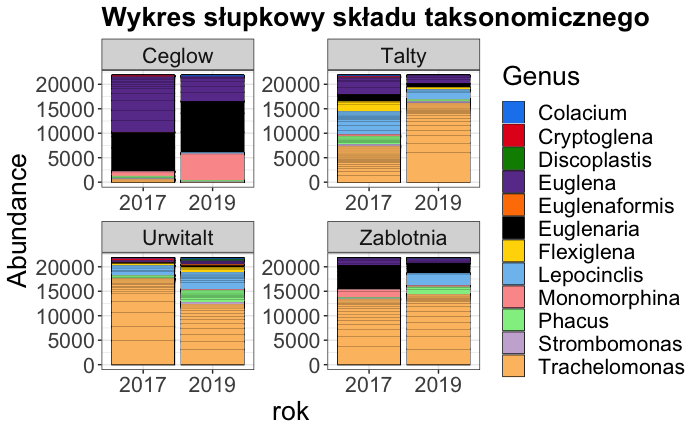

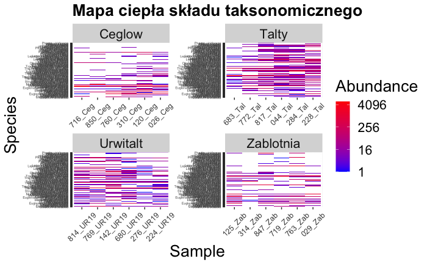

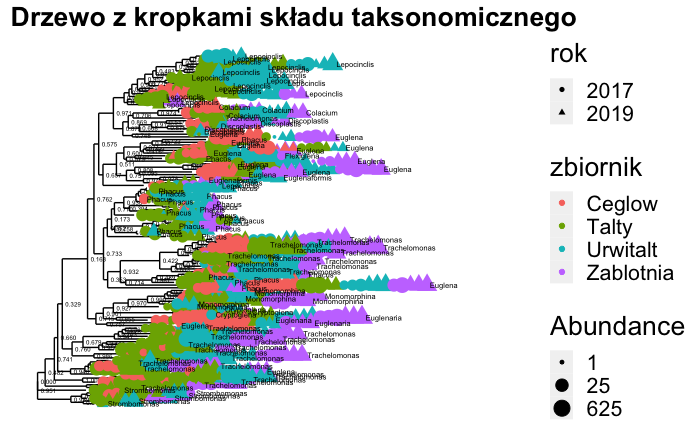